# Dynamic Lot Sizing in a Worksheet and in Code

Manuel D. Rossetti, PhD P.E.

## Agenda

- The five sheets of `Chapter5Models.xlsx`, and the cells that carry the mathematics
- The window costs, the recursion and the traceback laid out with nothing collapsed
- The three rules side by side, and the mixed integer program for Solver
- What the worksheet cannot do
- The software: a schedule that owns the window cost, one procedure for three rules, and the rule that does not fit
- The rolling horizon, the class that exists because a worksheet cannot do it

## The Five Sheets

| Sheet | What it does | Which part of the chapter |
| --- | --- | --- |
| `Data` | the requirements schedule, its statistics, and the forced period | the requirements schedule; when none of this is worth doing |
| `Plans` | four plans side by side, each costed by its ledger | three plans without any theory |
| `WagnerWhitin` | the window costs, the recursion, the traceback, the plan | the window cost; the recursion |
| `Heuristics` | three triangles of scores, the stopping tests, the chains and plans | three heuristics and one shape |
| `Solver` | the mixed integer program, one row per period | the same problem for a solver |

**The periods run down the rows** of one block, and every sheet reads that block by name. Blue cells are inputs, gray cells are computed, and **yellow** marks a cell a method picked: a period an order starts in, or a period a stopping rule chose.

## `Data`: Three Inputs and Everything Else

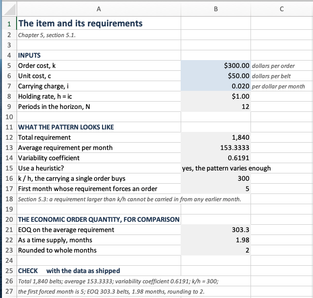

The three inputs in rows 5 to 7 are the only typed numbers on the sheet, and everything below them follows.

Notice that every figure the check block in rows 25 to 27 promises is on the screen above it: 1,840 belts, an average of 153.3333, a variability coefficient of **0.6191**, $k/h = 300$, a first forced month of **5**, and an economic order quantity of **303.3** belts, a time supply of 1.98 months.

Cell B15 reads the variability coefficient against the threshold of 0.2 and answers the question in words, rather than leaving the reader to compare two numbers.

## `Data`: the Requirements Schedule

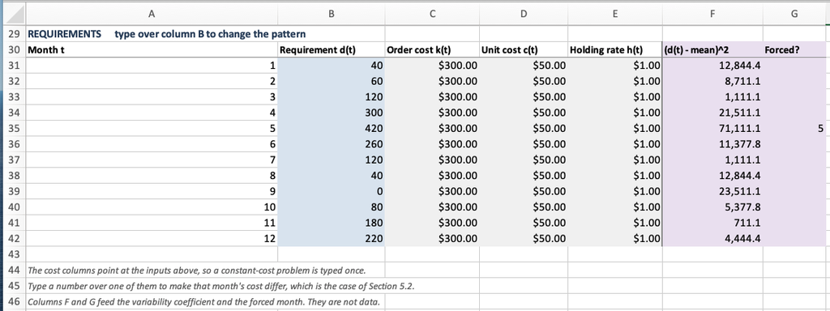

Column B is the only blue block. Columns C, D and E point at the input cells above, so a constant-cost problem is typed once, and a period-varying one needs no second workbook: type $54 over one cell of the unit cost column and every window cost in the workbook accounts for the price rise.

Notice column G, empty except in month 5, where 420 belts exceed $k/h = 300$ and the forced-order test fires. Columns F and G are tinted, because they are derived and not data.

## `Plans`: the Ledger, Made General

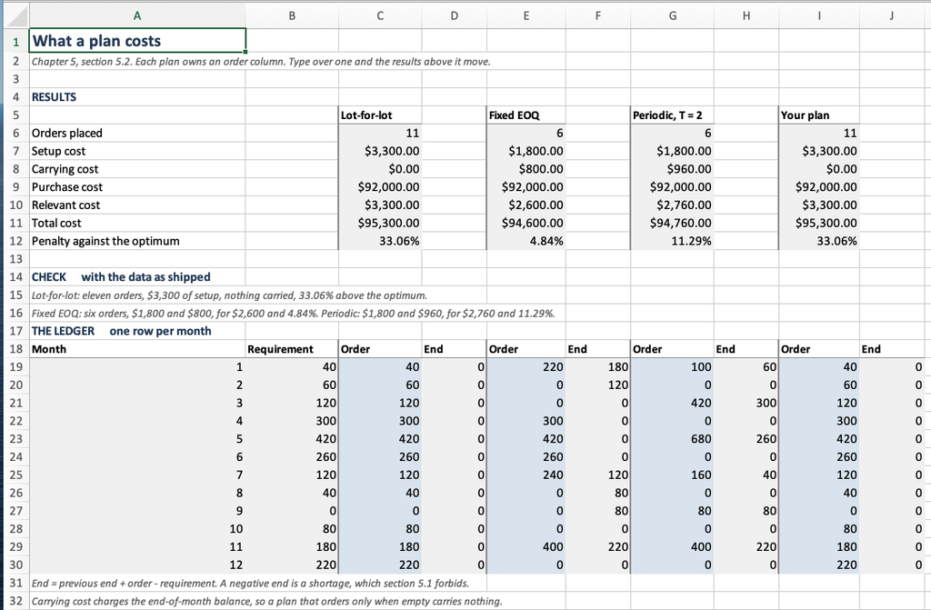

Four plans side by side, each an order column you type into and an ending-inventory column computing `= previous end + order - requirement`. The three shipped plans reproduce the three plans without theory exactly. Notice the purchase cost: **$92,000 under all four plans**, the purchase term made visible.

## `WagnerWhitin`: the Answer

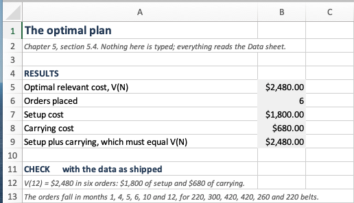

Nothing on this sheet is typed. The top block is the answer, and row 9 exists to be compared with row 5: the setup and carrying of the traced plan must add to $V(N)$.

Rather than write the window cost out in each cell, each cell adds one period to the cell on its left:

$$\begin{aligned}
w(t,t) &= k_t
&&\text{diagonal}\\
w(t,u) &= w(t,u-1) + d_u \sum_{r=t}^{u-1} h_r
&&\text{one more period}
\end{aligned}$$

That is one short formula, filled right and down, and with constant $h$ the step is $h(u - t)d_u$, the increment read along row 1 of the window table.

## `WagnerWhitin`: the Window Triangle

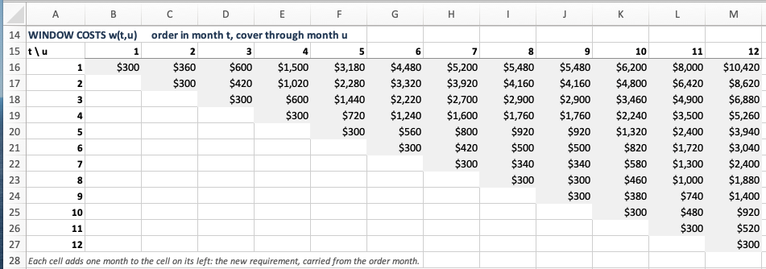

This is the six-month window table extended to twelve; read row 1 across and the first six entries are that table. Notice columns 8 and 9: equal in every row, because month 9 requires nothing, so a window reaching it costs what one ending at month 8 costs.

Notice also how fast the upper right grows. Covering the whole year from month 1 costs **$10,420** against $300 for a single month, and that ratio is the whole reason an optimal plan orders more than once.

## `WagnerWhitin`: the Recursion and the Traceback

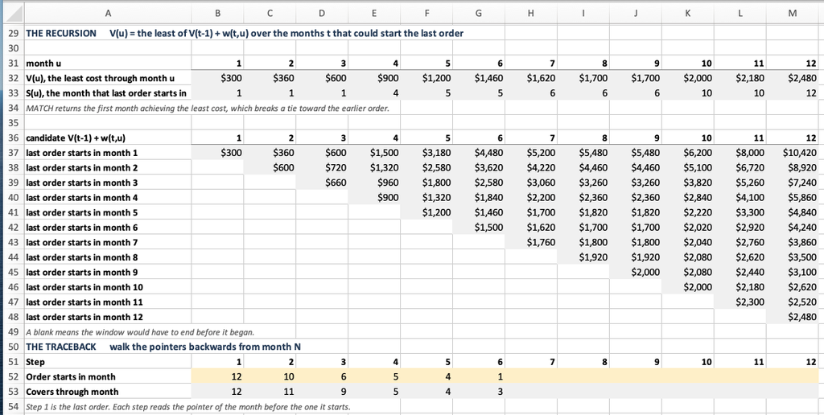

The candidate block holds $V(t-1) + w(t,u)$ for every $t$ and $u$, with nothing collapsed: $V(u)$ is the `MIN` down column $u$ and $S(u)$ is the `MATCH` of that minimum. Notice $V(8) = V(9) = \$1{,}700$ with $S = 6$ at both. The yellow row is the traceback, walked backward by `INDEX` on the $S$ row, and read right to left it orders in months 1, 4, 5, 6, 10 and 12.

## `WagnerWhitin`: the Plan

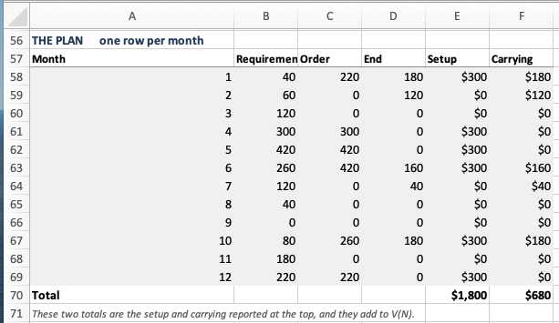

The chain has become an order quantity per month, with `COUNTIF` asking whether a period starts an order and `INDEX(Dls_d,a):INDEX(Dls_d,b)` totaling what it covers.

The two totals are the arithmetic check the sheet is built around: **$1,800** of setup and **$680** of carrying, which add to $V(12) = \$2{,}480$.

## `Heuristics`: Silver-Meal’s Scores and Its Stopping Test

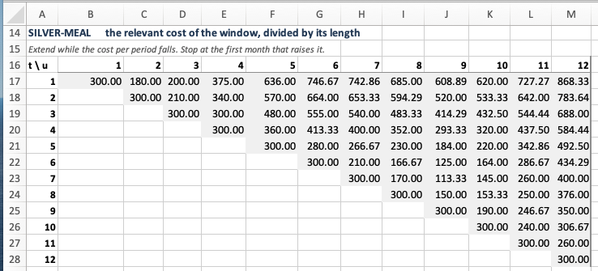

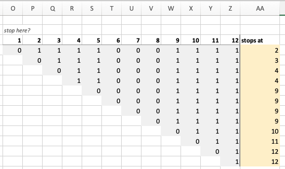

Every score is a window cost divided by the length of its window. Row 5 is where the rule loses its money: $300.00, $280.00, $266.67, $230.00, $184.00, and only then a rise. Beside the scores, a triangle of zeros and ones asks “does the score rise at the next period?”, and `MATCH(1, ...)` finds the stop. Notice the yellow column: 2, 3, 4, 4, then **9 four times over**.

## `Heuristics`: Least Unit Cost and Part-Period Balancing

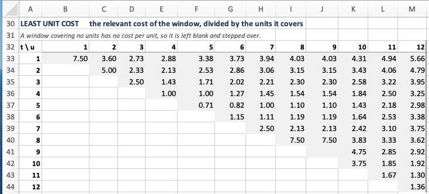

**Least unit cost** changes only the divisor. Notice the blank on the diagonal at $t = u = 9$: a window covering no units has no cost per unit, so the rule steps over it. It is the only cell in the workbook that has to be guarded.

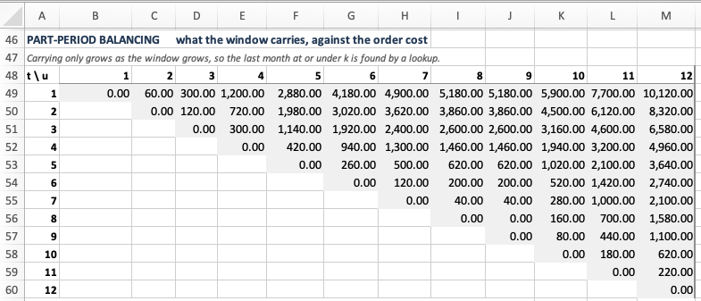

**Part-period balancing** scores what the window carries, which only grows. So the last period at or under $k_t$ is an ordinary ascending `MATCH`, and the two neighbors are compared. Row 1 finds $300 exactly at $u = 3$.

The two walking rules need a triangle of stopping tests; part-period balancing needs a lookup and a comparison. A score that can fall, as Silver-Meal’s can, cannot be looked up that way. The software draws the same line.

## `Heuristics`: the Chains and the Plans

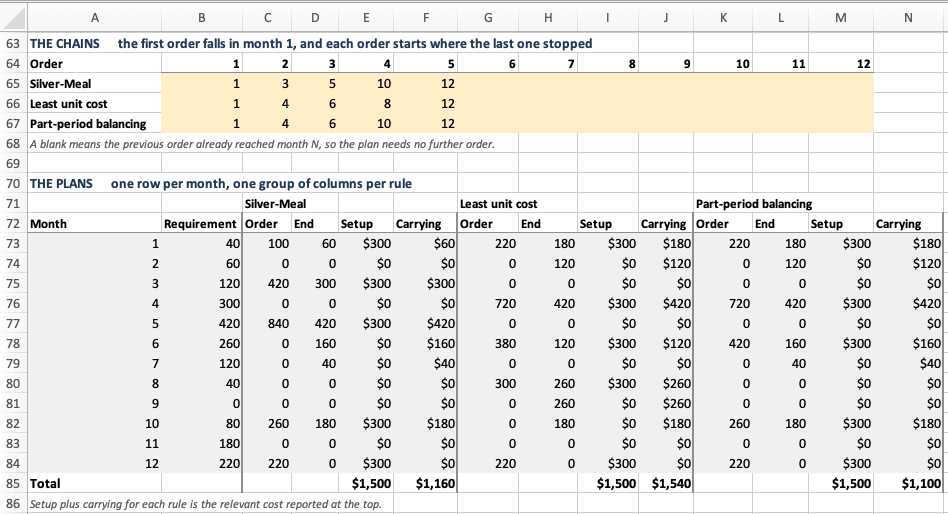

Each chain starts in month 1, and each order after it starts where the previous one stopped. The rules order in months 1, 3, 5, 10, 12; in 1, 4, 6, 8, 12; and in 1, 4, 6, 10, 12. All three place five orders and **no two agree on where**. The totals are $1,500 of setup in every case against carrying of $1,160, $1,540 and $1,100.

## `Solver`: the Mixed Integer Program

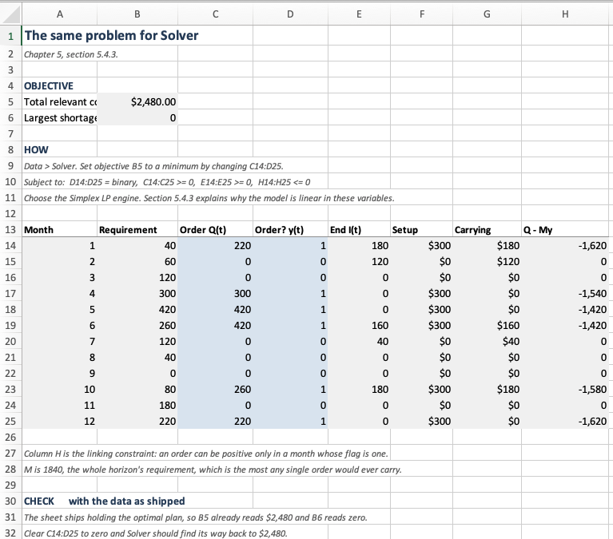

One row per period: $Q_t$ in column C and $y_t$ in column D are the changing cells, and column H holds $Q_t - M y_t$, which Solver keeps at or below zero. That single column is what makes the program linear.

The sheet ships holding the optimal plan, so B5 reads $2,480. Clear the two changing columns and Solver finds its way back.

Notice column H in the months that order: a large negative number. The linking constraint is **slack** there and binds only at zero, which is its job.

## What the Worksheet Cannot Do

The rolling horizon is not in the workbook, and that is not an oversight.

The rolling-horizon table is the cost of a sequence of twelve plans, eleven of which were computed, discarded and never executed. The study of 2,000 random schedules needs each solved twelve times under two rules:

$$2{,}000 \times 12 \times 2 = 48{,}000 \text{ solves}.$$

A worksheet asked to do that stops being a thing anyone can read.

A worksheet is the right tool for a model you want to **look at**, and the wrong tool for a model you want to **run many times**. That is where the software begins.

## What the Software Must Do, and Its Nouns

1. Hold a requirements schedule, with costs that may vary by period.
2. Price any window $w(t,u)$.
3. Evaluate a plan someone else chose.
4. Produce a plan under any of the seven rules.
5. Report one plan’s penalty against another.
6. Roll a horizon forward, committing part of each plan.

Requirement 6 is the one the worksheet could not meet, and the reason for writing a program at all.

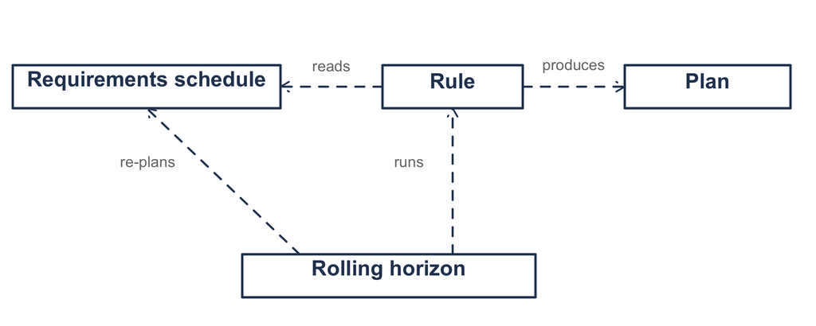

Three nouns survive: a **schedule** is what the planner is handed, a **plan** is what the planner produces, and a **rule** is how one becomes the other.

*Window* and *order* are the instructive rejections. A window has no behavior and no life of its own: $w(t,u)$ is a function of the schedule and two integers. An order is $Q_t$, a number in a position, and every question about it is a question about a plan.

## What Each Thing Knows and Does

| Class | Knows and does | Collaborates with |
| --- | --- | --- |
| `RequirementsSchedule` | the requirements and the three cost streams; $d[t,u]$; $\hat{c}(t,s)$; the window cost; the variability coefficient; the forced order period | `LotSizingPlan` |
| `LotSizingPlan` | the order quantities; ending inventory; setup, purchase and carrying; whether it orders only when empty; its penalty against another plan | `RequirementsSchedule` |
| `LotSizingRule` | how far a replenishment should reach | `RequirementsSchedule`, `LotSizingPlan` |
| `RollingHorizon` | the true schedule, the planning window, the frozen span; what the committed orders actually cost | all three |

**The schedule owns the window cost.** Every rule prices the same windows, so computing them in one place means the heuristics and the algorithm are compared on identical numbers.

Notice what the plan does **not** store: its ending inventory. The balance equation determines it from the orders, so storing both would allow a plan whose inventory no sequence of orders produces. And the plan refuses a shortage in its constructor, so every plan anywhere in the program is feasible.

## The Schedule Prices Every Window

```kotlin
fun windowCost(from: Int, through: Int): Double {
    requireWindow(from, through)
    val key = (from - 1) * horizon + (through - 1)
    cached[key]?.let { return it }
    val value = k[from - 1] + (from..through).sumOf { unitCostHeld(from, it) * d[it - 1] }
    cached[key] = value
    return value
}

fun relevantWindowCost(from: Int, through: Int): Double =
    orderCostIn(from) + carryingCostOver(from, through)
```

`windowCost` is $w(t,u) = k_t + \sum_s d_s\,\hat{c}(t,s)$, with `unitCostHeld` as $\hat{c}$, memoized because every rule asks for the same $N(N+1)/2$ values.

**Two window costs, and the difference is not cosmetic**

The recursion may use `windowCost`, purchase term and all: the same constant added to every plan changes no comparison. A rule that **divides by the length of the window** may not. The purchase term grows with the window while the setup does not, so a cost per period built on it falls simply because the window is longer, and Silver-Meal would extend to the end of the horizon on every instance.

## Three Rules Are One Rule

If the three heuristics are one procedure, the code should contain it once:

```kotlin
abstract class WindowRule(override val name: String) : LotSizingRule {
    protected abstract fun scoreOf(schedule: RequirementsSchedule, from: Int, through: Int): Double?

    final override fun plan(schedule: RequirementsSchedule): LotSizingPlan {
        val orders = mutableListOf<Int>()
        var from = 1
        while (from <= schedule.horizon) {
            orders.add(from)
            from = 1 + lastPeriodCovered(schedule, from)
        }
        return schedule.planFrom(orders)
    }

    fun lastPeriodCovered(schedule: RequirementsSchedule, from: Int): Int {
        var best = from
        var previous: Double? = null
        for (through in from..schedule.horizon) {
            val score = scoreOf(schedule, from, through) ?: continue
            if (previous != null && score > previous + TOLERANCE) break
            previous = score
            best = through
        }
        return best
    }
}
```

`lastPeriodCovered` is the walk: extend, score, stop at the first rise, and keep the period before it. A `null` score is skipped, not compared.

## Two Rules in Three Lines Each

```kotlin
object SilverMeal : WindowRule("Silver-Meal") {
    override fun scoreOf(schedule: RequirementsSchedule, from: Int, through: Int): Double =
        schedule.relevantWindowCost(from, through) / (through - from + 1)
}

object LeastUnitCost : WindowRule("Least unit cost") {
    override fun scoreOf(schedule: RequirementsSchedule, from: Int, through: Int): Double? {
        val units = schedule.requirementOver(from, through)
        return if (units <= 0.0) null else schedule.relevantWindowCost(from, through) / units
    }
}
```

That is the rule table, executable. The nullable return is least unit cost’s one irregularity: a window covering no units has no cost per unit, so the rule steps over it. Month 9 of the belt is such a period, and it is the cell the worksheet had to guard.

## The Rule That Does Not Fit

```kotlin
object PartPeriodBalancing : LotSizingRule {
    fun lastPeriodCovered(schedule: RequirementsSchedule, from: Int): Int {
        val setup = schedule.orderCostIn(from)
        var best = from
        for (through in from + 1..schedule.horizon) {
            val carried = schedule.carryingCostOver(from, through)
            if (carried > setup) {
                val below = schedule.carryingCostOver(from, through - 1)
                return if (abs(carried - setup) < abs(below - setup)) through else through - 1
            }
            best = through
        }
        return best
    }
}
```

It walks a gap to its closest approach, and the period it keeps may be **the one before the test failed**. That cannot be written as a score walked to a minimum, so it implements the interface directly.

A template method earns its place when three things share a shape, and should be abandoned the moment a fourth only appears to.

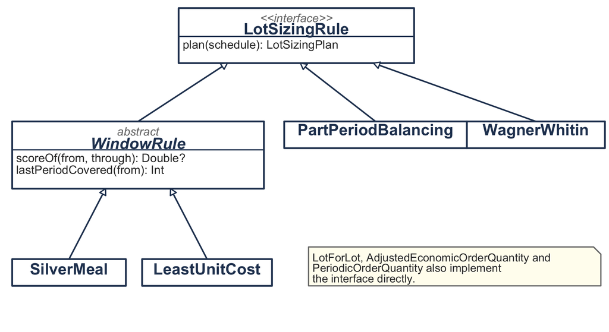

## The Algorithm Is Not a Heuristic

```kotlin
object WagnerWhitin : LotSizingRule {
    fun solve(schedule: RequirementsSchedule): Solution {
        val n = schedule.horizon
        val value = DoubleArray(n + 1)
        val from = IntArray(n + 1)
        for (t in 1..n) {
            var best = Double.MAX_VALUE
            var argument = 1
            for (s in 1..t) {
                val candidate = value[s - 1] + schedule.windowCost(s, t)
                if (candidate < best - TOLERANCE) {
                    best = candidate
                    argument = s
                }
            }
            value[t] = best
            from[t] = argument
        }
        ...
    }
}
```

`value` is $V$ and `from` is $S$; the strict comparison keeps the earliest period on a tie, the same one `MATCH` finds on the worksheet. `solve` returns $V$ and $S$ as well as the plan, because a reader checking the traceback needs the pointers.

## How the Objects Solve It

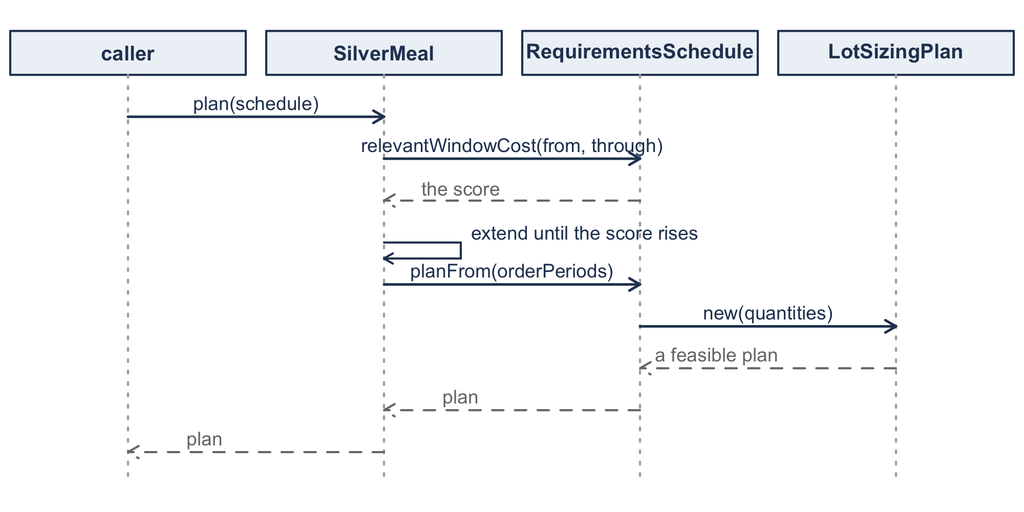

Notice that the rule computes **no cost of its own**. It decides which costs to ask for. That is what lets the comparison table rank the rules on their decisions and not on their arithmetic.

## Rolling the Horizon

```kotlin
fun realizedPlan(rule: LotSizingRule): LotSizingPlan {
    val n = actual.horizon
    val placed = DoubleArray(n)
    var period = 1
    while (period <= n) {
        val onHand = carriedInto(placed, period)
        val committedTo = minOf(period + freeze - 1, n)
        val net = netRequirements(period, minOf(period + planningHorizon - 1, n), onHand)
        if (net != null) {
            val plan = rule.plan(net.window)
            for (t in period..committedTo) {
                val offset = t - net.firstPlanned + 1
                if (offset in 1..net.window.horizon) placed[t - 1] = plan.orderIn(offset)
            }
        }
        period = committedTo + 1
    }
    return LotSizingPlan(actual, placed.toList())
}
```

The subtle part is `netRequirements`. The planner may be holding stock from an earlier order, and a schedule starts empty, so the stock on hand is netted against the nearest requirements, as a requirements record nets it. Getting this wrong produces a plan that orders on top of stock it already has.

## Solving the Chapter’s Examples

```kotlin
val belt = RequirementsSchedule.constantCosts(
    label = "Mower deck belt",
    requirements = listOf(40.0, 60.0, 120.0, 300.0, 420.0, 260.0,
                          120.0, 40.0, 0.0, 80.0, 180.0, 220.0),
    orderCost = 300.0, unitCost = 50.0, carryingCharge = 0.02,
)
println(belt.variabilityCoefficient)   // 0.6191
println(belt.forcedOrderPeriod())      // 5

val optimum = WagnerWhitin.plan(belt)
for (r in listOf(LotForLot, AdjustedEconomicOrderQuantity(), PeriodicOrderQuantity(),
                 LeastUnitCost, PartPeriodBalancing, SilverMeal, WagnerWhitin)) {
    val p = r.plan(belt)
    println("%-32s %6d %9.0f %9.0f %9.0f %8.2f%%".format(
        r.name, p.orderCount, p.setupCost, p.carryingCost, p.relevantCost,
        p.penaltyAgainst(optimum).relativeError * 100.0))
}

for (window in 2..6) {
    val sm = RollingHorizon(belt, window, freeze = 1).realizedPlan(SilverMeal)
    val ww = RollingHorizon(belt, window, freeze = 1).realizedPlan(WagnerWhitin)
    println("%d %.0f %.0f".format(window, sm.relevantCost, ww.relevantCost))
}
```

The comparison of every method is a **loop over rules**, and that is what the design was for. The rolling-horizon table is two lines per row.

## What We Did Today

**The workbook lays every method out with nothing collapsed:** the window triangle, the candidate block, the traceback, and the three rules’ scores, each checked against the chapter.

**The schedule owns the window cost,** so every rule is compared on identical numbers, and the heuristics divide the **relevant** window cost.

**Silver-Meal and least unit cost are one procedure,** a template with a score; part-period balancing can step back and implements the interface directly, in code and in the worksheet both.

**Wagner-Whitin is not a heuristic,** and returns $V$ and $S$ as well as the plan.

**The rolling horizon is a class** because a worksheet holds one instance of a model and cannot run 48,000.

## For Next Time

**Read before next session:** *Demand You Should Not Forecast*, *The Bill of Material* and *The MRP Record*, in the requirements planning chapter.

Today’s material was *Building These Models in a Worksheet* and *Designing the Software*.

Next session:

- Where requirements come from when they are calculated rather than forecast
- The bill of material, and why an item needs a low-level code
- The six-row MRP record, worked by hand

Every rule from today runs inside an MRP record unchanged. Bring the belt’s twelve-month pattern: it becomes a master production schedule.

⌂ Index